# MDAG workshop: Part 4b Creating your website

Author

J Nienkemper-Swanepoel

# Before you start

- You should have a **GitHub** account. Please refer to the `Part4a` document for detailed steps.

# Using the website template

- Sign into your **GitHub** account.
- The website template is available in this repository: jnienk/createQuarto_website (open this in a new window).
- Click on `Use this template` and `Create a new repository`:

[figure not shown]

- Decide on a name for your repository and leave all other fields as is. Click on `Create repository`:

[figure not shown]

  *Take note: for the website to render, the repository has to be public, which is the default setting.*
- The repository should open on your GitHub account and should look similar to the screen capture below.

[figure not shown]

- To ensure that the website it visible, follow these steps:
  - Click on `Settings`:

[figure not shown]

  - Click on `Pages`:

[figure not shown]

  - Click on `None`:

[figure not shown]

  - Select `Main`:

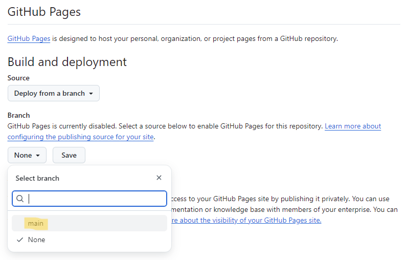

  - Click on `/(root)`:

[figure not shown]

  - Select `/docs` and and click on `Save`:

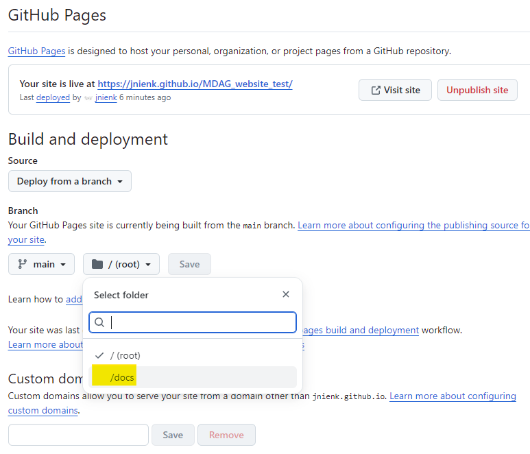

- Navigate back to your repository by clicking on the repository name in the left corner:

[figure not shown]

- Link the `GitHub Pages` to your repository by clicking on the *gear icon*:

[figure not shown]

- Enable `Use your GitHub Pages website` and click on `Save changes`:

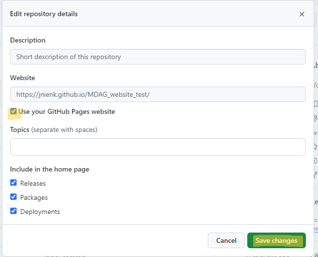

- Click on `Code` and `Download ZIP`:

[figure not shown]

- Once the download is complete, extract all files in a location that will be easy to locate again.

[figure not shown]

- **OPTIONAL**: If you have a profile photo you would like to use, add this to the main folder with the extracted documents. This should be a `.png` format.
- Open the R project file: `createQuarto_website.Rproj`

[figure not shown]

- Follow the next steps to update your own website.

## YAML file

A YAML file (`.yml`) is a text file that is easy to read and used for the configuration of your website. This will include the layout of the pages and order of the tabs. In this version of the website you will have a (1) Home page, (2) Educational background page, (3) Presentation page and (4) Blog posts. You can add more pages as you develop the content for your website.

- Navigate to the `Files` pane (typically in the right bottom corner of your `RStudio` session). Click on the `_quarto.yml` file to start making changes in `RStudio`.
- Add your name and surname in line 7. Do not remove the quotations.
- Update the `site-url` in line 9 by removing the `#` and `copy-and-paste` your GitHub repository URL from **GitHub**. The format should be: `https://github.com/<GitHub account name>/<repository name>`.
- Add your Name and Surname in the Copyright statement in line 29.
- Do not make any other changes.
- Save the `.yml` to ensure all changes are captured.
- **Take note**: Line 22 and 23 are commented out. If you have an activated [ORCID iD](https://orcid.org/) profile, you can remove the `#` in both these lines and refer to the **Publications page** section towards the end of this document.

## Index file

The index file is the home page of your website.

- Again, navigate to the `Files` pane (typically in the right bottom corner of your `RStudio` session). Click on the `index.qmd` file to make the following changes in `RStudio`.
- Add your initials and surname in line 2. Again, do not remove the quotations.
- If you have added a profile picture, change the file name in line 8 which is currently `profile.png`.
- **OPTIONAL** sections that can be commented out:
  - Add your email address in line 13.
  - Add your [Google Scholar](https://scholar.google.com/) account URL in line 17.
  - Add your [ORCID iD](https://orcid.org/) URL in line 19.
  - Add your [LinkedIn profile](https://www.linkedin.com/home) URL in line 21.  
    *You can add or remove items here, just remember to keep the `- icon:` and `href:` per item when adding more. Simply `copy-and-paste` the other items and edit as required.*
- Write a short biography under in the provided section between `::: :::`. Do not remove these colons.
- Save the `.qmd` to ensure all changes are captured.

## Education page

- Again, navigate to the `Files` pane (typically in the right bottom corner of your `RStudio` session). Click on the `education.qmd` to make the following changes in `RStudio`.
- Tables have been created to provide a skeleton for your information.
- More sections can be added by creating additional headings.
- Save the `.qmd` to ensure all changes are captured.

## Talks page

- The editing of this page happens outside of `RStudio`.
- Open the `talks.csv` file in `Microsoft Excel` (or equivalent application).
- **Important**: Do not change the headings (row 1) of this file, only add rows below the heading row.
- Add relevant information on presentations you have delivered.
- Do not make any changes in the `talks.qmd` file.

## Blog posts

- A preliminary folder has been created in the `posts` folder in the repository: `2025-11-25-my-first-blog-post`.
- In the future, you will add a new folder for each blog post in the `posts` folder. You can decide on a naming convention, but it works best to start with the date, followed by the title of the post. *Take note: spaces are indicated with a hyphen.*
- Inside each blog post folder, you should have a `Quarto` document file named `index.qmd`. As before, *GitHub* recognises `index` files as home pages and therefore, this file name should never be changed.
- Do not make any changes in the `blog.qmd` file.
- Open the `posts/2025-11-25-my-first-blog-post/index.qmd` file in`RStudio`.
- You can make changes to the title, author and date fields. Again, do not remove the quotations.
- You can add categories by using the same formatting of line 7 and 8.
- You can add tags by using the same formatting of line 10 and 11.
- Try to add one of your examples from **Part 3** of the workshop for your first blog post.

## Publications

**This is an additional website setting, which is only applicable if you have an active ORCID iD.**

- It is possible to automatically sync your ORCID iD profile with `RStudio` to create an updated list of your publications.
- Include your ORCID iD number in line 16.
- Remember to remove the comments (`#`) in line 22 and 23 in the `_quarto.yml` if you want to include a publication page on your website.

## Rendering the website

- Ensure that all changes are saved.
- In the `Environment window` select `Build`:

[figure not shown]

- Click on `Render Website`:

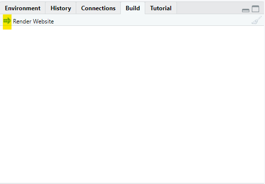

- If you have followed all the steps exactly, you should see the following output in the `Background Jobs` window:

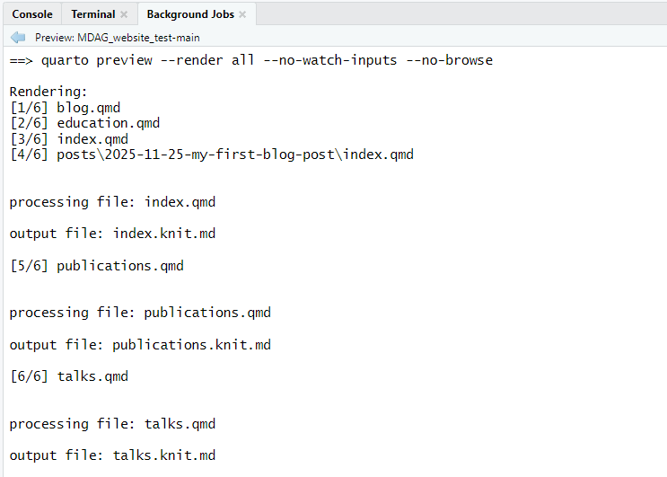

- The website will render in the `Viewer` tab:

[figure not shown]

- You can click on `Show in new window` to view this in the browser.

## Publishing the website

- These changes will not reflect on **GitHub** yet.
- If you are not an experienced **GitHub** and **Git** user, the easiest way to `commit` all your changes to **GitHub** is to add them manually (**take note**: this approach is limited to uploading a 100 files). Therefore, try to be selective by only adding files that were changed and not selecting all files if they exceed a 100.
- Alternative steps are provided in the `Part 4c` document which is a more efficient approach to commit changes to repositories.
- In **GitHub** click on `Add file` and `Upload files`:

[figure not shown]

- You can simply select all files and `drop` them in the provided window in **GitHub**:

[figure not shown]

- Add a commit message and click on `Commit changes`:

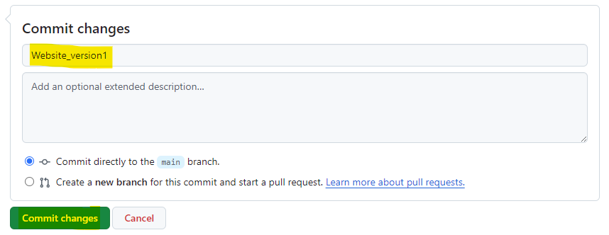

- Now you will have to wait for the changes to reflect. If a brown solid circle is visible, the process is still pending:

[figure not shown]

- The website is ready for viewing when a green tick mark appears:

[figure not shown]

- You can view the website by clicking on the link in the `About` section:

[figure not shown]

- Your website:

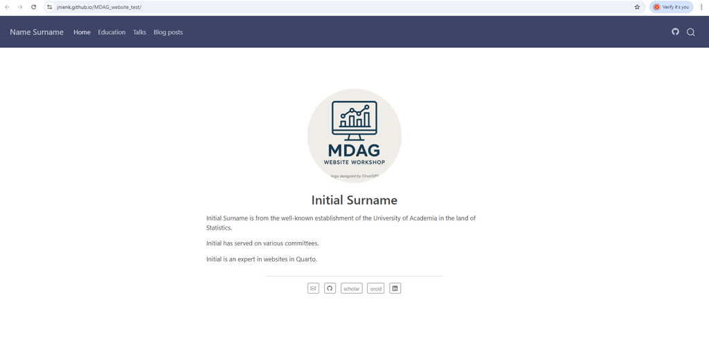

- This is also the URL you can use as your personal website address.